# Predicting the Juice Brand

Using Logistic Regression and Logistic Lasso Regression

Max Johansson

Spring of 2024

# 1. Introduction

In this brief project I analyze the ISLR2 data “OJ”, containing data on customers of two different brands of juice. I use logistic regression since the outcome variable is binary, however I also use logistic Lasso penalized regression since I discover that there is high correlation among many predictors.

# 2. Data Exploration

To begin with, I load the packages and data into the environment. I set the seed so that the results are replicable.

```r
# Load the packages:
library(ISLR2) # For the OJ data set
library(dplyr) # For the select() function and %>%
library(corrplot) # For the corrplot() function
library(RColorBrewer) # For the brewer.pal() function, color palette
library(glmnet) # For the glmnet() function
library(stargazer) # To compare summary output using the stargazer() function

# Load the data:
df <- ISLR2::OJ

# Set the seed:
set.seed(123456789)
```

```r
# Check the presence of NA's:
any_na <- any(is.na(df))

# Recode the outcome variable: 1 or 0:
df$Purchase <- ifelse(df$Purchase == "MM", 1, 0)

# The dimensions of the data:
dimensions <- dim(df)

# The class of each variable:
classes <- sapply(df, class)

# A for loop to transform some variables into factors
fact_df<- df[, c(1, 3, 8, 9, 14, 18)]
var_list <- colnames(fact_df)

for (i in var_list) {
  df[[i]] <- as.factor(df[[i]])
}

# I confirm the changes:
new_classes <- sapply(df, class)
```

For the numeric variables, I produce a correlation plot to get an idea of the correlations. It appears that many variables are highly correlated with at least some other variable, indicating multicollinearity drawbacks.

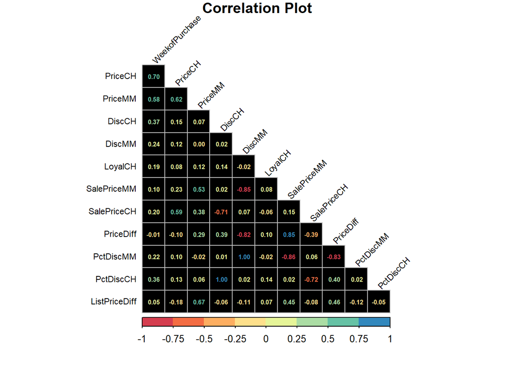

```r
# Numeric subset:
num_df <- df[, -c(1, 3, 8, 9, 14, 18)]

# Correlation matrix, the purchase variable:
corr_mat <- cor(num_df)

# Set a palette:
my_palette <- RColorBrewer::brewer.pal(8, "Spectral")

# Plot the correlations:
corrplot::corrplot(
  corr_mat,
  method = "number",
  type = "lower",
  diag = FALSE,
  col = my_palette,
  title = "Correlation Plot",
  mar = c(1, 1, 1, 1),
  bg = "black",
  tl.cex = 0.7,
  tl.col = "black",
  tl.srt = 45,
  number.cex = 0.50
)
```

# 3. Modelling

Since the outcome variable is binary, I use logistic regression. However, the high correlation among many variables is something I fear will affect the fitted model. To compare, I also perform a logistic Lasso regression.

## 3.1. Logistic Regression

I split the data into a fitting set and a validation set. As I summarize the model fitted on all variables, 9 variable coefficients are set to 0 as a consequence of singularities, indicating that multicollinearity is an issue here. Here I decide to handle the highly correlated variables in the data by separating them into different models.

```r
# Sampling mechanism:
sampling <- sample(c(TRUE, FALSE),
                   nrow(df),
                   replace = TRUE,
                   prob = c(0.75, 0.25))

# Fitting data 75%, validation data 25%:
fit <- df[sampling, ]

val <- df[!sampling, ]

# Logistic models:

logistic_model1 <- glm(Purchase ~ .,
                       data = fit[, -c(11:13, 15:17)],
                       family = binomial)

logistic_model2 <- glm(Purchase ~ .,
                       data = fit[, -c(5:7, 13)],
                       family = binomial)

stargazer::stargazer(logistic_model1,
                     logistic_model2,
                     type = "text")
```

```
##
## ==============================================
##                       Dependent variable:
##                   ----------------------------
##                             Purchase
##                        (1)            (2)
## ----------------------------------------------
## WeekofPurchase       -0.026*       -0.029**
##                      (0.014)        (0.014)
##
## StoreID2              0.124          0.006
##                      (0.331)        (0.343)
##
## StoreID3              -0.549        -0.642
##                      (0.454)        (0.458)
##
## StoreID4              -0.646        -0.739
##                      (0.504)        (0.508)
##
## StoreID7             -0.711**      -0.720**
##                      (0.342)        (0.341)
##
## PriceCH              6.778***       30.629
##                      (2.276)       (26.636)
##
## PriceMM             -2.693***
##                      (1.011)
##
## DiscCH               -2.876**
##                      (1.354)
##
## DiscMM               2.520***
##                      (0.654)
##
## SpecialCH1            0.432          0.540
##                      (0.389)        (0.403)
##
## SpecialMM1            0.411          0.455
##                      (0.335)        (0.337)
##
```

[output cut: 27 more lines]

```
## STORE3
##
##
## STORE4
##
##
## Constant              2.435         4.092*
##                      (2.158)        (2.425)
##
## ----------------------------------------------
## Observations           797            797
## Log Likelihood       -297.150      -295.751
## Akaike Inf. Crit.    620.301        621.502
## ==============================================
## Note:              *p<0.1; **p<0.05; ***p<0.01
```

I predict the probabilities of the outcomes, then transform them into predictions. The “MM” brand is treated as the “success” or “1” in this case, so if a predicted probability is above 50% then the prediction is “MM”. The most common outcome in the fitting data is “CH”, so I estimate the accuracy of the mode as a predictor as a benchmark. The logistic model performs better than the mode as a predictor.

```r
# I initialize an empty lists:
logistic_probs <- list()
logistic_preds <- list()

# A for loop, looping over the models:
for (i in 1:2) {
  if (i == 1) {
    logistic_probs[[i]] <- predict(logistic_model1,
                                   newdata = val,
                                   type = "response")
    logistic_preds[[i]] <- ifelse(logistic_probs[[i]] > 0.5, 1, 0)
  }
  else {
    logistic_probs[[i]] <- predict(logistic_model2,
                                   newdata = val,
                                   type = "response")
    logistic_preds[[i]] <- ifelse(logistic_probs[[i]] > 0.5, 1, 0)

  }
}

# Model 1 accuracy:
cat(100 * mean(logistic_preds[[1]] == val$Purchase),
    "% accuracy", "\n")
```

```
## 81.31868 % accuracy
```

```r
# Model 2 accuracy:
cat(100 * mean(logistic_preds[[2]] == val$Purchase),
    "% accuracy", "\n")
```

```
## 80.95238 % accuracy
```

```r
# Mode accuracy
cat(100 * mean(val$Purchase == "0"),
    "% accuracy", "\n")
```

```
## 64.10256 % accuracy
```

## 3.2. Logistic Lasso Regression

In the following code I fit the lasso model and predict the juice brand of the consumers in the validation data set.

```r
# The x must be a model.matrix and the y a numeric vector:
x_fit <- model.matrix(Purchase ~ ., fit)[, -1]
y_fit <- fit$Purchase == 1

x_val <- model.matrix(Purchase ~ ., val)[, -1]
y_val <- val$Purchase == 1

# Cross validation for the best lambda value:
cv.lambda <-
  glmnet::cv.glmnet(x_fit,
                    y_fit,
                    alpha = 1,
                    family = "binomial")

# Fit the lasso model:
lasso_model <-
  glmnet::glmnet(x_fit,
                 y_fit,
                 family = "binomial",
                 alpha = 1,
                 lambda = cv.lambda$lambda.min)

# Coefficients of the model:
lasso_coef <- coef(lasso_model)

# Predictions:
lasso_prob <- predict.glmnet(lasso_model,
                 newx = x_val,
                 type = "response")

lasso_pred <- ifelse(lasso_prob > 0.5,
                     "TRUE",
                     "FALSE")
```

From the output it is clear that a number of variable coefficients have been reduced to 0. The accuracy is about the same as the logistic models.

```r
# Print the Coefficients:
print(lasso_coef)
```

```
## 24 x 1 sparse Matrix of class "dgCMatrix"
##                          s0
## (Intercept)     3.402336378
## WeekofPurchase -0.001447469
## StoreID2        0.124673279
## StoreID3        .
## StoreID4        .
## StoreID7       -0.347811267
## PriceCH         .
## PriceMM         .
## DiscCH          .
## DiscMM          .
## SpecialCH1      .
## SpecialMM1      0.194572481
## LoyalCH        -5.957611311
## SalePriceMM     .
## SalePriceCH     .
## PriceDiff      -2.382835512
## Store7Yes       .
## PctDiscMM       .
## PctDiscCH       .
## ListPriceDiff   .
## STORE1          .
## STORE2          0.007632213
## STORE3          .
## STORE4          .
```

```r
# Print the Accuracy:
cat(100 * mean(lasso_pred == y_val),
    "% accuracy",
    "\n")
```

```
## 79.85348 % accuracy
```

# 5. Findings

All logistic models yield prediction accuracy of around 80%, which is better than the performance of the mode as a prediction for all values.

# 6. Packages

ISLR2: https://cran.r-project.org/package=ISLR2 dplyr: https://cran.r-project.org/package=dplyr corrplot: https://cran.r-project.org/package=corrplot RColorBrewer: https://cran.r-project.org/package=RColorBrewer gplots: https://cran.r-project.org/package=gplots glmnet: https://cran.r-project.org/package=glmnet stargazer: https://cran.r-project.org/package=stargazer